# Jobs and prices across Europe, in plain SQL

Monthly unemployment (2005 onwards, total and under-25) and consumer price inflation (2015 onwards, for all items, food, housing and energy, and transport) for about 40 European countries from Eurostat. Eight questions in SQL only: ranking countries with `RANK`, change against a year earlier with `LAG(..., 12)`, peaks and the months since with `ROW_NUMBER`, a pivot by conditional aggregation, a correlation coefficient built from sums, and a gaps-and-islands query for the longest runs of falling unemployment. Python only runs the queries and draws the charts.

**Data:** the [Eurostat](https://ec.europa.eu/eurostat) dissemination API (`une_rt_m` and `prc_hicp_manr`), free to reuse with attribution. Run `python build_db.py` once to download the series (about 3 MB) into a SQLite database, then point `EUROSTAT_DB` at that file.

**Reading the data.** Unemployment is the seasonally adjusted share of the labour force. Inflation is the annual rate of change of the harmonised index (HICP). Countries report with different lags, so a "latest month" differs a little between them, and some series stop early (the United Kingdom's unemployment ends in September 2020). The EU and euro-area aggregates are used as benchmarks and left out of the country rankings.

```python
import os
import sqlite3
from pathlib import Path

import matplotlib.pyplot as plt
import numpy as np
import pandas as pd

DB_PATH = Path(os.environ.get("EUROSTAT_DB", "eurostat.db"))
AMBER, BLUE, GREY = "#e8a33d", "#2b6cb0", "#a0aec0"
plt.rcParams.update({"axes.spines.top": False, "axes.spines.right": False, "axes.grid": True,
                     "grid.alpha": 0.25, "figure.dpi": 110})
pd.set_option("display.width", 120)
pd.set_option("display.max_columns", 20)

con = sqlite3.connect(DB_PATH)


def q(sql):
    """Run a query and return the result as a DataFrame."""
    return pd.read_sql_query(sql, con)
```

## 0. What is in the database?

```python
tables = q("SELECT name FROM sqlite_master WHERE type = 'table' ORDER BY name").name
pd.DataFrame({"table": tables,
              "rows": [con.execute(f'SELECT COUNT(*) FROM "{t}"').fetchone()[0] for t in tables]})
```

|  | table | rows |
| --- | --- | --- |
| 0 | categories | 4 |
| 1 | countries | 48 |
| 2 | inflation | 22956 |
| 3 | unemployment | 9540 |

## 1. Which countries have the highest unemployment right now?

`ROW_NUMBER() OVER (PARTITION BY country ORDER BY month DESC)` finds each country's latest month, and `LAG(rate, 12)` inside the same CTE gives the value a year earlier. `RANK()` then orders the countries. Only countries with data from 2026 are shown.

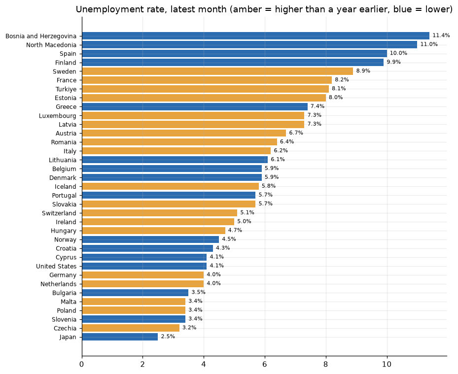

|  | rank | country | month | unemployment_pct | change_vs_year_ago | under25_pct |
| --- | --- | --- | --- | --- | --- | --- |
| 0 | 1 | Bosnia and Herzegovina | 2026-07 | 11.4 | -0.7 | NaN |
| 1 | 2 | North Macedonia | 2026-08 | 11.0 | -0.8 | NaN |
| 2 | 3 | Spain | 2026-08 | 10.0 | -0.5 | 22.7 |
| 3 | 4 | Finland | 2026-08 | 9.9 | -0.2 | 22.8 |
| 4 | 5 | Sweden | 2026-08 | 8.9 | 0.2 | 23.0 |
| 5 | 6 | France | 2026-08 | 8.2 | 0.4 | 20.6 |
| 6 | 7 | Turkiye | 2026-07 | 8.1 | 0.0 | 14.5 |
| 7 | 8 | Estonia | 2026-08 | 8.0 | 0.8 | 28.4 |

```python
latest = q("""
WITH series AS (
    SELECT country_code, month, rate_total, rate_youth,
           LAG(rate_total, 12) OVER (PARTITION BY country_code ORDER BY month)  AS year_ago,
           ROW_NUMBER()        OVER (PARTITION BY country_code ORDER BY month DESC) AS rn
    FROM unemployment
)
SELECT RANK() OVER (ORDER BY s.rate_total DESC)  AS rank,
       c.country,
       s.month,
       s.rate_total                              AS unemployment_pct,
       ROUND(s.rate_total - s.year_ago, 1)       AS change_vs_year_ago,
       s.rate_youth                              AS under25_pct
FROM series s
JOIN countries c USING (country_code)
WHERE s.rn = 1 AND c.is_aggregate = 0 AND s.month >= '2026-01'
ORDER BY s.rate_total DESC
""")

fig, ax = plt.subplots(figsize=(8.5, 7))
colors = [BLUE if v < 0 else AMBER for v in latest.change_vs_year_ago.fillna(0)]
ax.barh(latest.country[::-1], latest.unemployment_pct[::-1], color=colors[::-1])
for y, v in enumerate(latest.unemployment_pct[::-1]):
    ax.text(v + 0.1, y, f"{v:.1f}%", va="center", fontsize=7)
ax.set_title("Unemployment rate, latest month (amber = higher than a year earlier, blue = lower)")
ax.tick_params(axis="y", labelsize=8)
fig.tight_layout()
plt.show()
latest.head(8)
```

## 2. Is youth unemployment a different problem?

The same latest-month CTE, now comparing the under-25 rate with the overall rate. The ratio says how many times likelier a young active person is to be out of work than the average.

```python
youth = q("""
WITH series AS (
    SELECT country_code, month, rate_total, rate_youth,
           ROW_NUMBER() OVER (PARTITION BY country_code ORDER BY month DESC) AS rn
    FROM unemployment
    WHERE rate_total IS NOT NULL AND rate_youth IS NOT NULL
)
SELECT c.country, s.month,
       s.rate_total                          AS overall_pct,
       s.rate_youth                          AS under25_pct,
       ROUND(s.rate_youth / s.rate_total, 1) AS youth_to_overall_ratio
FROM series s
JOIN countries c USING (country_code)
WHERE s.rn = 1 AND c.is_aggregate = 0 AND s.month >= '2026-01'
ORDER BY under25_pct DESC
LIMIT 12
""")

youth
```

|  | country | month | overall_pct | under25_pct | youth_to_overall_ratio |
| --- | --- | --- | --- | --- | --- |
| 0 | Romania | 2026-06 | 6.8 | 30.8 | 4.5 |
| 1 | Bosnia and Herzegovina | 2026-06 | 11.4 | 30.3 | 2.7 |
| 2 | Estonia | 2026-08 | 8.0 | 28.4 | 3.5 |
| 3 | North Macedonia | 2026-06 | 11.1 | 28.1 | 2.5 |
| 4 | Sweden | 2026-08 | 8.9 | 23.0 | 2.6 |
| 5 | Finland | 2026-08 | 9.9 | 22.8 | 2.3 |
| 6 | Spain | 2026-08 | 10.0 | 22.7 | 2.3 |
| 7 | Luxembourg | 2026-08 | 7.3 | 20.8 | 2.8 |
| 8 | France | 2026-08 | 8.2 | 20.6 | 2.5 |
| 9 | Italy | 2026-08 | 6.2 | 20.3 | 3.3 |
| 10 | Portugal | 2026-08 | 5.7 | 19.8 | 3.5 |
| 11 | Belgium | 2026-06 | 6.3 | 19.1 | 3.0 |

## 3. How bad did the crisis years get, and who recovered?

Two `ROW_NUMBER` rankings per country (by unemployment, highest first, and by month, latest first) pick the peak and the most recent value in one pass, using conditional aggregation to put them on one row.

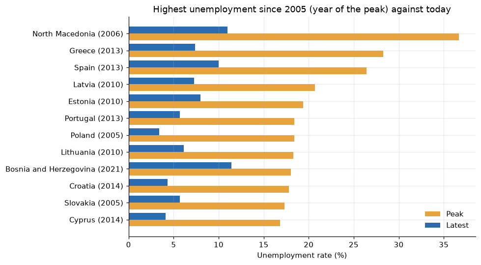

|  | country | peak_pct | peak_month | latest_pct | latest_month | fall_since_peak |
| --- | --- | --- | --- | --- | --- | --- |
| 0 | North Macedonia | 36.7 | 2006-08 | 11.0 | 2026-08 | 25.7 |
| 1 | Greece | 28.3 | 2013-07 | 7.4 | 2026-08 | 20.9 |
| 2 | Spain | 26.4 | 2013-02 | 10.0 | 2026-08 | 16.4 |
| 3 | Latvia | 20.7 | 2010-01 | 7.3 | 2026-08 | 13.4 |
| 4 | Estonia | 19.4 | 2010-03 | 8.0 | 2026-08 | 11.4 |
| 5 | Portugal | 18.4 | 2013-02 | 5.7 | 2026-08 | 12.7 |
| 6 | Poland | 18.4 | 2005-06 | 3.4 | 2026-08 | 15.0 |
| 7 | Lithuania | 18.3 | 2010-07 | 6.1 | 2026-08 | 12.2 |
| 8 | Bosnia and Herzegovina | 18.0 | 2021-01 | 11.4 | 2026-07 | 6.6 |
| 9 | Croatia | 17.8 | 2014-03 | 4.3 | 2026-08 | 13.5 |
| 10 | Slovakia | 17.3 | 2005-01 | 5.7 | 2026-08 | 11.6 |
| 11 | Cyprus | 16.8 | 2014-03 | 4.1 | 2026-08 | 12.7 |

```python
peaks = q("""
WITH ranked AS (
    SELECT country_code, month, rate_total,
           ROW_NUMBER() OVER (PARTITION BY country_code ORDER BY rate_total DESC, month DESC) AS peak_rn,
           ROW_NUMBER() OVER (PARTITION BY country_code ORDER BY month DESC)                  AS last_rn
    FROM unemployment
    WHERE rate_total IS NOT NULL
)
SELECT c.country,
       MAX(CASE WHEN peak_rn = 1 THEN rate_total END)              AS peak_pct,
       MAX(CASE WHEN peak_rn = 1 THEN month END)                   AS peak_month,
       MAX(CASE WHEN last_rn = 1 THEN rate_total END)              AS latest_pct,
       MAX(CASE WHEN last_rn = 1 THEN month END)                   AS latest_month,
       ROUND(MAX(CASE WHEN peak_rn = 1 THEN rate_total END)
           - MAX(CASE WHEN last_rn = 1 THEN rate_total END), 1)    AS fall_since_peak
FROM ranked r
JOIN countries c USING (country_code)
WHERE c.is_aggregate = 0
GROUP BY r.country_code
HAVING latest_month >= '2026-01'
ORDER BY peak_pct DESC
LIMIT 12
""")

fig, ax = plt.subplots(figsize=(9, 5))
y = np.arange(len(peaks))
ax.barh(y + 0.2, peaks.peak_pct, height=0.4, color=AMBER, label="Peak")
ax.barh(y - 0.2, peaks.latest_pct, height=0.4, color=BLUE, label="Latest")
ax.set_yticks(y, [f"{c} ({m[:4]})" for c, m in zip(peaks.country, peaks.peak_month)])
ax.invert_yaxis()
ax.set_xlabel("Unemployment rate (%)")
ax.set_title("Highest unemployment since 2005 (year of the peak) against today")
ax.legend(frameon=False)
fig.tight_layout()
plt.show()
peaks
```

## 4. How has Poland compared with the EU average?

Conditional aggregation pivots Poland and the EU-27 average into two columns of one monthly table, so the gap between them is a simple subtraction.

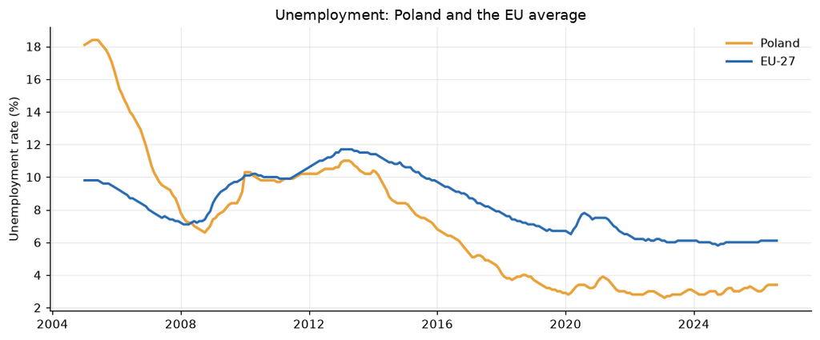

|  | month | poland | eu27 | gap |
| --- | --- | --- | --- | --- |
| 0 | 2005-01 | 18.1 | 9.8 | 8.3 |
| 130 | 2015-11 | 7.2 | 9.8 | -2.6 |
| 259 | 2026-08 | 3.4 | 6.1 | -2.7 |

```python
poland = q("""
SELECT month,
       MAX(CASE WHEN country_code = 'PL'        THEN rate_total END) AS poland,
       MAX(CASE WHEN country_code = 'EU27_2020' THEN rate_total END) AS eu27,
       ROUND(MAX(CASE WHEN country_code = 'PL'        THEN rate_total END)
           - MAX(CASE WHEN country_code = 'EU27_2020' THEN rate_total END), 1) AS gap
FROM unemployment
WHERE country_code IN ('PL', 'EU27_2020')
GROUP BY month
HAVING poland IS NOT NULL AND eu27 IS NOT NULL
ORDER BY month
""")

x = pd.to_datetime(poland.month)
fig, ax = plt.subplots(figsize=(9.5, 4))
ax.plot(x, poland.poland, color=AMBER, lw=2.2, label="Poland")
ax.plot(x, poland.eu27, color=BLUE, lw=2, label="EU-27")
ax.set_ylabel("Unemployment rate (%)")
ax.set_title("Unemployment: Poland and the EU average")
ax.legend(frameon=False)
fig.tight_layout()
plt.show()
poland.iloc[[0, len(poland) // 2, -1]]
```

## 5. Where did the 2022 price shock hit hardest?

`ROW_NUMBER() OVER (PARTITION BY country ORDER BY annual_rate DESC)` finds each country's peak year-on-year inflation (all items) and the month it happened.

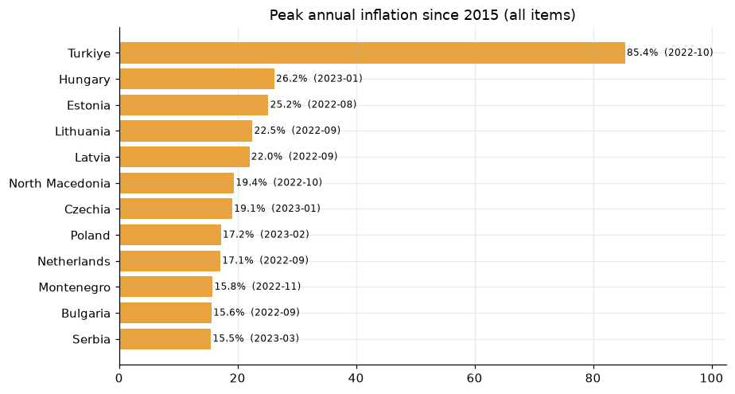

|  | rank | country | peak_month | peak_inflation_pct |
| --- | --- | --- | --- | --- |
| 0 | 1 | Turkiye | 2022-10 | 85.4 |
| 1 | 2 | Hungary | 2023-01 | 26.2 |
| 2 | 3 | Estonia | 2022-08 | 25.2 |
| 3 | 4 | Lithuania | 2022-09 | 22.5 |
| 4 | 5 | Latvia | 2022-09 | 22.0 |
| 5 | 6 | North Macedonia | 2022-10 | 19.4 |
| 6 | 7 | Czechia | 2023-01 | 19.1 |
| 7 | 8 | Poland | 2023-02 | 17.2 |
| 8 | 9 | Netherlands | 2022-09 | 17.1 |
| 9 | 10 | Montenegro | 2022-11 | 15.8 |
| 10 | 11 | Bulgaria | 2022-09 | 15.6 |
| 11 | 12 | Serbia | 2023-03 | 15.5 |

```python
inflation_peak = q("""
WITH ranked AS (
    SELECT country_code, month, annual_rate,
           ROW_NUMBER() OVER (PARTITION BY country_code ORDER BY annual_rate DESC) AS rn
    FROM inflation
    WHERE coicop = 'CP00'
)
SELECT RANK() OVER (ORDER BY r.annual_rate DESC) AS rank,
       c.country,
       r.month        AS peak_month,
       r.annual_rate  AS peak_inflation_pct
FROM ranked r
JOIN countries c USING (country_code)
WHERE r.rn = 1 AND c.is_aggregate = 0
ORDER BY r.annual_rate DESC
LIMIT 12
""")

fig, ax = plt.subplots(figsize=(8.5, 4.6))
ax.barh(inflation_peak.country[::-1], inflation_peak.peak_inflation_pct[::-1], color=AMBER)
for y, (v, m) in enumerate(zip(inflation_peak.peak_inflation_pct[::-1], inflation_peak.peak_month[::-1])):
    ax.text(v + 0.3, y, f"{v:.1f}%  ({m})", va="center", fontsize=8)
ax.set_xlim(0, inflation_peak.peak_inflation_pct.max() * 1.2)
ax.set_title("Peak annual inflation since 2015 (all items)")
fig.tight_layout()
plt.show()
inflation_peak
```

## 6. What drove prices up: food, energy or transport?

Conditional aggregation pivots four price categories into columns for the EU as a whole, so their year-on-year inflation can be compared month by month.

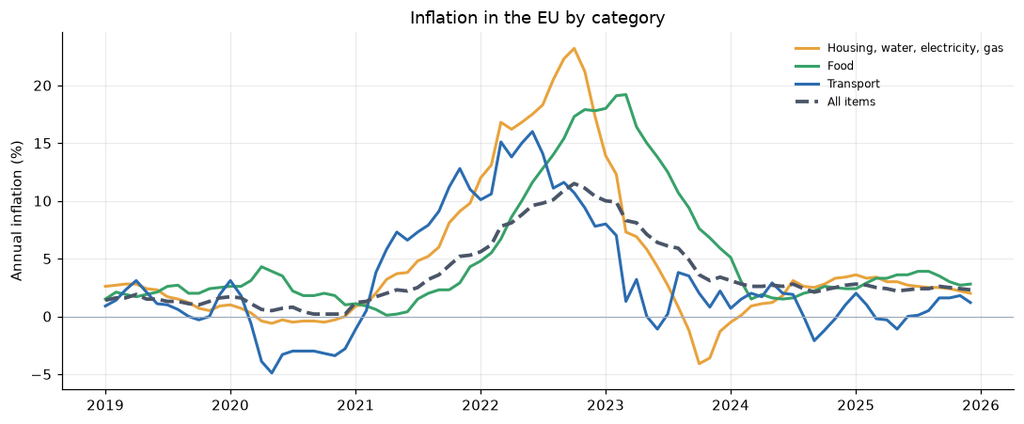

|  | month | all_items | food | housing_and_energy | transport |
| --- | --- | --- | --- | --- | --- |
| 45 | 2022-10 | 11.5 | 17.3 | 23.2 | 10.7 |
| 50 | 2023-03 | 8.3 | 19.2 | 7.3 | 1.3 |
| 41 | 2022-06 | 9.6 | 11.6 | 17.5 | 16.0 |

```python
categories = q("""
SELECT month,
       MAX(CASE WHEN coicop = 'CP00' THEN annual_rate END) AS all_items,
       MAX(CASE WHEN coicop = 'CP01' THEN annual_rate END) AS food,
       MAX(CASE WHEN coicop = 'CP04' THEN annual_rate END) AS housing_and_energy,
       MAX(CASE WHEN coicop = 'CP07' THEN annual_rate END) AS transport
FROM inflation
WHERE country_code = 'EU27_2020' AND month >= '2019-01'
GROUP BY month
ORDER BY month
""")

x = pd.to_datetime(categories.month)
fig, ax = plt.subplots(figsize=(10, 4.2))
ax.plot(x, categories.housing_and_energy, color=AMBER, lw=2, label="Housing, water, electricity, gas")
ax.plot(x, categories.food, color="#38a169", lw=2, label="Food")
ax.plot(x, categories.transport, color=BLUE, lw=2, label="Transport")
ax.plot(x, categories.all_items, color="#4a5568", lw=2.5, ls="--", label="All items")
ax.axhline(0, color=GREY, lw=0.8)
ax.set_ylabel("Annual inflation (%)")
ax.set_title("Inflation in the EU by category")
ax.legend(frameon=False, fontsize=8)
fig.tight_layout()
plt.show()
categories.loc[[categories.housing_and_energy.idxmax(), categories.food.idxmax(), categories.transport.idxmax()]]
```

## 7. Do countries with higher unemployment have lower inflation?

Yearly averages per country are joined, and the correlation coefficient across countries is computed for each year from sums (`n*Σxy - Σx*Σy` over the square roots of the variances). A negative value would match the textbook trade-off between unemployment and inflation.

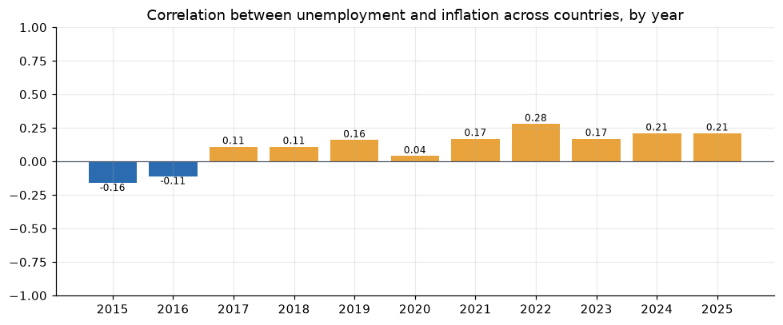

|  | year | countries | correlation |
| --- | --- | --- | --- |
| 0 | 2015 | 34 | -0.16 |
| 1 | 2016 | 34 | -0.11 |
| 2 | 2017 | 34 | 0.11 |
| 3 | 2018 | 34 | 0.11 |
| 4 | 2019 | 34 | 0.16 |
| 5 | 2020 | 34 | 0.04 |
| 6 | 2021 | 33 | 0.17 |
| 7 | 2022 | 33 | 0.28 |
| 8 | 2023 | 33 | 0.17 |
| 9 | 2024 | 33 | 0.21 |
| 10 | 2025 | 32 | 0.21 |

```python
phillips = q("""
WITH u AS (
    SELECT country_code, substr(month, 1, 4) AS year, AVG(rate_total) AS unemployment
    FROM unemployment WHERE rate_total IS NOT NULL
    GROUP BY country_code, year
),
i AS (
    SELECT country_code, substr(month, 1, 4) AS year, AVG(annual_rate) AS inflation
    FROM inflation WHERE coicop = 'CP00'
    GROUP BY country_code, year
),
joined AS (
    SELECT u.year, u.unemployment AS x, i.inflation AS y
    FROM u JOIN i USING (country_code, year)
    JOIN countries c USING (country_code)
    WHERE c.is_aggregate = 0 AND u.year BETWEEN '2015' AND '2025'
),
sums AS (
    SELECT year, COUNT(*) AS n, SUM(x) AS sx, SUM(y) AS sy, SUM(x * y) AS sxy, SUM(x * x) AS sxx, SUM(y * y) AS syy
    FROM joined GROUP BY year
)
SELECT year, n AS countries,
       ROUND((n * sxy - sx * sy) / (sqrt(n * sxx - sx * sx) * sqrt(n * syy - sy * sy)), 2) AS correlation
FROM sums
ORDER BY year
""")

fig, ax = plt.subplots(figsize=(9, 3.8))
ax.bar(phillips.year, phillips.correlation, color=[BLUE if v < 0 else AMBER for v in phillips.correlation])
for x, v in enumerate(phillips.correlation):
    ax.text(x, v + (0.02 if v >= 0 else -0.06), f"{v:.2f}", ha="center", fontsize=8)
ax.axhline(0, color="#4a5568", lw=0.8)
ax.set_ylim(-1, 1)
ax.set_title("Correlation between unemployment and inflation across countries, by year")
fig.tight_layout()
plt.show()
phillips
```

## 8. Which country had the longest run of falling unemployment?

A **gaps-and-islands** query. `LAG` flags every month in which unemployment did not rise, and the difference between a country's overall month number and its month number within the flag stays constant for as long as a run lasts, so grouping by it collapses each run into one row.

```python
streaks = q("""
WITH changes AS (
    SELECT country_code, month, rate_total,
           rate_total - LAG(rate_total) OVER (PARTITION BY country_code ORDER BY month) AS delta
    FROM unemployment
    WHERE rate_total IS NOT NULL
),
flagged AS (
    SELECT *, delta <= 0 AS not_rising,
           ROW_NUMBER() OVER (PARTITION BY country_code ORDER BY month) AS month_no
    FROM changes
    WHERE delta IS NOT NULL
),
numbered AS (
    SELECT *, ROW_NUMBER() OVER (PARTITION BY country_code, not_rising ORDER BY month) AS flag_no
    FROM flagged
)
SELECT c.country,
       COUNT(*)              AS months_in_a_row,
       MIN(n.month)          AS from_month,
       MAX(n.month)          AS to_month,
       ROUND(SUM(n.delta), 1) AS change_pp
FROM numbered n
JOIN countries c USING (country_code)
WHERE n.not_rising = 1 AND c.is_aggregate = 0
GROUP BY n.country_code, n.month_no - n.flag_no
ORDER BY months_in_a_row DESC, from_month
LIMIT 8
""")

streaks
```

|  | country | months_in_a_row | from_month | to_month | change_pp |
| --- | --- | --- | --- | --- | --- |
| 0 | Germany | 81 | 2013-02 | 2019-10 | -2.2 |
| 1 | Spain | 69 | 2013-08 | 2019-04 | -12.0 |
| 2 | Croatia | 61 | 2015-02 | 2020-02 | -11.1 |
| 3 | Slovakia | 52 | 2015-02 | 2019-05 | -6.7 |
| 4 | Germany | 43 | 2005-05 | 2008-11 | -4.2 |
| 5 | Poland | 42 | 2005-05 | 2008-10 | -11.8 |
| 6 | Germany | 41 | 2009-08 | 2012-12 | -2.6 |
| 7 | Netherlands | 39 | 2016-03 | 2019-05 | -3.2 |

## What the queries say

**Limits:** countries report with different lags, so "latest" is a different month for each (all in 2026); the UK series stops in 2020; the unemployment definitions follow Eurostat's harmonised method, so they can differ from national figures; averages across countries treat a small economy and a large one equally.

**Techniques covered:** `ROW_NUMBER` and `RANK` per group, `LAG` with an offset of 12, conditional-aggregation pivots, a correlation coefficient from sums, CTE chains and a gaps-and-islands query.